# Chapter 3: Logistic regression

This document is a report on RStudio exercise 3 on the IODS course. The goal is to study factors having an effect on alcohol consumption. The source of the dataset is the UCI Machine Learning Library; [here](https://archive.ics.uci.edu/ml/datasets/STUDENT+ALCOHOL+CONSUMPTION) is a link to where the dataset can be downloaded.

## Getting started

Let us start by downloading the dataset from the `data` folder.

```r
alc <- read.table("/Users/ollisilvennoinen/IODS-project/data/alc.csv", sep = ",", header = TRUE)
```

We then continue by looking at the columns in the data file:

```r
colnames(alc)
```

```
##  [1] "X"          "school"     "sex"        "age"        "address"
##  [6] "famsize"    "Pstatus"    "Medu"       "Fedu"       "Mjob"
## [11] "Fjob"       "reason"     "nursery"    "internet"   "guardian"
## [16] "traveltime" "studytime"  "failures"   "schoolsup"  "famsup"
## [21] "paid"       "activities" "higher"     "romantic"   "famrel"
## [26] "freetime"   "goout"      "Dalc"       "Walc"       "health"
## [31] "absences"   "G1"         "G2"         "G3"         "alc_use"
## [36] "high_use"
```

The dataset contains a number of background variables as well as the variable that we are interested in studying, i.e., `high_use`, whether a given participant has high alcohol use or not. The page that contains the data files (linked above) also provides information on the variables. There are 35 variables and 382 observations (in addition, there is a column that gives a unique identifying integer for each observation).

In this assignment, I shall examine the effects of the following variables on high alcohol use:  
* `sex`: my hypothesis is that males use alcohol more than females  
* `age` (ranging from 15 to 22): my hypothesis is that the older the student, the more likely they are to display high use of alcohol  
* `Medu` (ranging from 0 to 4 on an ordinal scale, 0 being low and 4 high education): my hypothesis is that when a child’s mother has low educational attainment, the child is more likely to use alcohol; this is based on the assumption that the mother’s educational attainment is a reliable indicator of the social status of the family (so I do not assume a causal relationship from the mother’s education to their child’s alcohol use)  
* `G3` (average of final period grade in math and Portuguese, ranging from 0 to 20): my hypothesis is that the lower the grade, the higher the likelihood of high alcohol use

## Initial explorations of the variables

Let us begin by considering each variable in isolation, starting with sex. Here is the breakdown of high users of alcohol by gender (note that TRUE means that the informant is a high user of alcohol). As the cross-tabulation shows, men seem to be more likely to be high users.

```r
table(alc$high_use, alc$sex)
```

```
##
##           F   M
##   FALSE 156 112
##   TRUE   42  72
```

Next up is the age of the informants, which I visualise using a boxplot; for this, I need the `ggplot2` package.

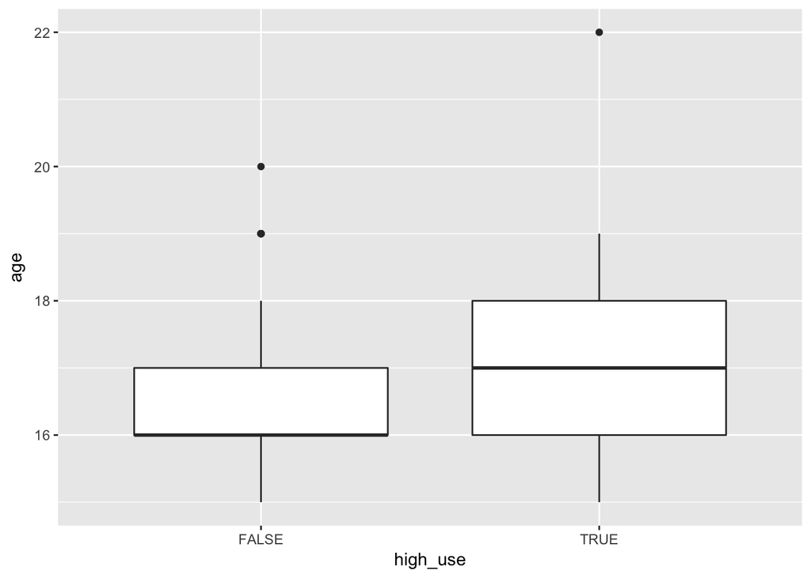

```r
library(ggplot2)
g1 <- ggplot(alc, aes(x = high_use, y = age))
g1 + geom_boxplot() + ylab("age")
```

As the boxplot shows, those who are coded as being high users are older on average, as my original hypothesis predicted.

Third, I look at `Medu`, this time using a mosaic plot.

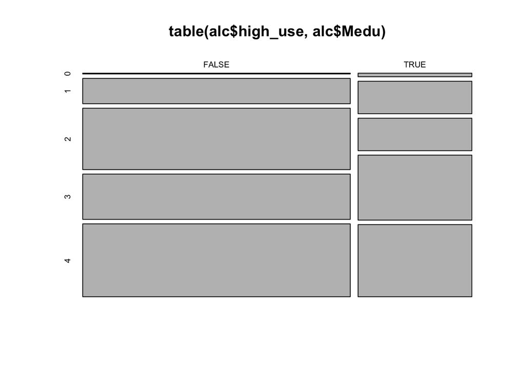

```r
plot(table(alc$high_use, alc$Medu))
```

The verdict for my hypothesis is mixed: getting 1 is more common for the high user group, but so is getting 3.

Finally, I shall have a look at final grades and high alcohol use.

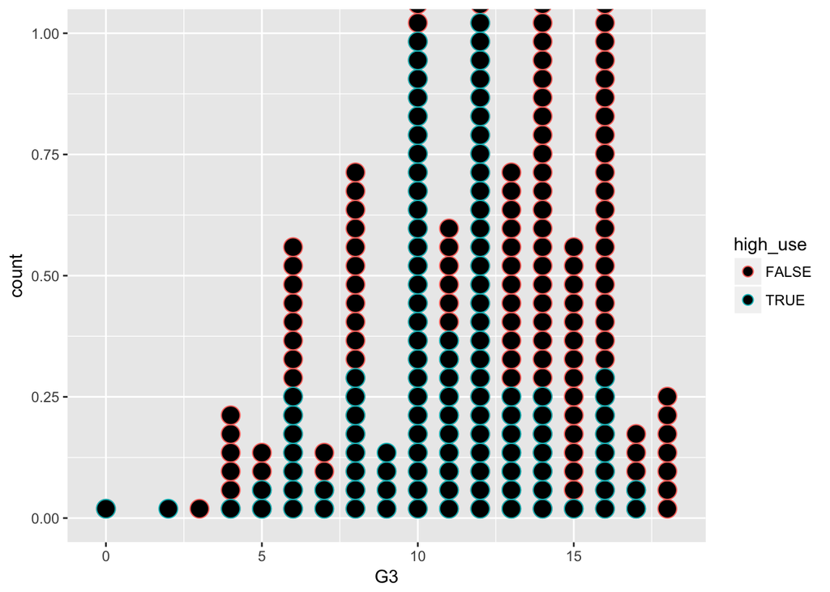

```r
g2 <- ggplot(alc, aes(x = G3, col = high_use))
g2 + geom_dotplot()
```

It seems that FALSE is more common towards the upper end of the grade scale while the TRUEs are concentrated towards the middle. This would support my hypothesis.

## Logistic regression

I now fit a logistic regression model on the dataset, using the `glm` function.

```r
m <- glm(high_use ~ sex + age + Medu + G3, data = alc, family = "binomial")
summary(m)
```

```
##
## Call:
## glm(formula = high_use ~ sex + age + Medu + G3, family = "binomial",
##     data = alc)
##
## Deviance Residuals:
##     Min       1Q   Median       3Q      Max
## -1.5188  -0.8574  -0.6693   1.2185   2.0521
##
## Coefficients:
##             Estimate Std. Error z value Pr(>|z|)
## (Intercept) -3.69109    1.82693  -2.020 0.043344 *
## sexM         0.87831    0.23478   3.741 0.000183 ***
## age          0.18551    0.10004   1.854 0.063691 .
## Medu         0.06228    0.11103   0.561 0.574830
## G3          -0.07838    0.03616  -2.168 0.030171 *
## ---
## Signif. codes:  0 '***' 0.001 '**' 0.01 '*' 0.05 '.' 0.1 ' ' 1
##
## (Dispersion parameter for binomial family taken to be 1)
##
##     Null deviance: 465.68  on 381  degrees of freedom
## Residual deviance: 440.90  on 377  degrees of freedom
## AIC: 450.9
##
## Number of Fisher Scoring iterations: 4
```

I now compute the confidence intervals.

```r
library(dplyr)
OR <- coef(m) %>% exp
CI <- confint(m) %>% exp
cbind(OR, CI)
```

```
##                     OR        2.5 %    97.5 %
## (Intercept) 0.02494492 0.0006625863 0.8709274
## sexM        2.40684013 1.5257844762 3.8361931
## age         1.20383314 0.9907875565 1.4680981
## Medu        1.06426277 0.8572699654 1.3260686
## G3          0.92460997 0.8605396713 0.9919652
```

## Predictions

Lastly, I check how well the model manages to predict the observations.

```r
probabilities <- predict(m, type = "response")
alc <- mutate(alc, probability = probabilities)
alc <- mutate(alc, prediction = alc$probability > 0.5)
table(high_use = alc$high_use, prediction = alc$probability > 0.5)
```

```
##         prediction
## high_use FALSE TRUE
##    FALSE   258   10
##    TRUE    103   11
```

The value ‘FALSE’ is predicted with a high accuracy. By contrast, ‘TRUE’ is quite weakly predicted. Therefore, the model requires a bit more work.